# The CMB data

In this section we will learn about the CMB data from WMAP (http://map.gsfc.nasa.gov/) and Planck (http://www.esa.int/Our_Activities/Space_Science/Planck). The goals of the exercise are:

- Download the WMAP and Planck data from this website:

  http://irsa.ipac.caltech.edu/data/Planck/release_2/ancillary-data/

  File: http://irsa.ipac.caltech.edu/data/Planck/release_2/ancillary-data/cosmoparams/COM_CosmoParams_fullGrid_R2.00.tar.gz

  This data comes from: http://pla.esac.esa.int/pla/#cosmology
- The description of the data and cosmological parameters is here:

  https://wiki.cosmos.esa.int/planckpla2015/index.php/Cosmological_Parameters

  and here:

  http://wiki.cosmos.esa.int/planckpla2015/images/b/b9/Parameter_tag_definitions_2015.pdf
- If you don't have python, we recommend using the Anaconda package, which should have all the modules needed:

  https://www.anaconda.com/download/

  Once you have it installed, you can start an Jupyter noebook with a terminal command

  $ jupyter notebook

  or follow instructions here: https://jupyter-notebook-beginner-guide.readthedocs.io/en/latest/execute.html
- To plot the distribution, use the corner plot:

  https://github.com/dfm/corner.py/blob/master/corner/corner.py

  more details: https://corner.readthedocs.io/en/latest/
- Example how to plot the constraints from WMAP are below
- Different cosmological models are in different folders. Here are examples:

  base - base flat Lambda-CDM model (use plikHM_TTTEEE_lowTEB)

  base_w - base flat Lambda-CDM model with varying Dark Energy equation of state w (use plikHM_TTTEEE_lowTEB)

  base_w_wa - base flat Lambda-CDM model with varying Dark Energy equation of state w, which can evolve with scale factor (use plikHM_TTTEEE_lowTEB_BAO)

  base_omegak - Lambda-CDM model with varying curvature (use plikHM_TTTEEE_lowTEB)
- Combination of different datasets used are in subfolders, for example:

  plikHM_TTTEEE_lowTEB - using Planck Temperature - Temperature (TT) and Temperature - E-mode-polarisation (TE) and E-mode-polarisation - E-mode-polarisation (EE) power spectra, low l-range of Cls

  plikHM_TTTEEE_lowTEB_BAO - as above, but use also use BAO data (Baryon Accoustic Oscillations will be covered later in the course)

  WMAP - use WMAP data

# Example - how to load the data

```python
import numpy as np
import pylab as pl
import pandas as pd
%pylab inline
from corner import corner
```

# Load the WMAP data

```python
# MCMC chain samples
samples = np.loadtxt('COM_CosmoParams_fullGrid_R2.00/base/WMAP/base_WMAP_1.txt')

# load the column names for the samples
column_names_raw = np.loadtxt('data/COM_CosmoParams_fullGrid_R2.00/base/WMAP/base_WMAP.paramnames', dtype=np.str, usecols=[0])
column_names = [x.replace("b'",'').replace("'",'') for x in column_names_raw]

# make a data frame with column names and samples
samples1 = pd.DataFrame(samples[:,2:], columns=column_names) # first two columns are not important
```

```python
# define which parameters to use
use_params = ['omegam*', 'omegabh2']
```

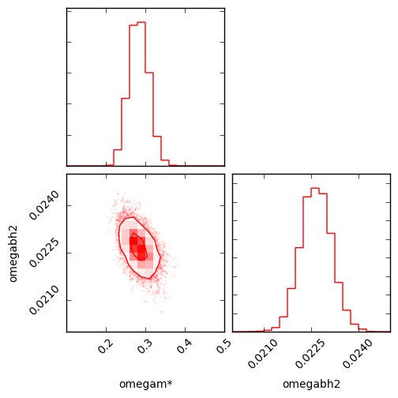

```python
pl.figure()
sigma1 = 1. - exp(-(1./1.)**2/2.)
sigma2 = 1. - exp(-(2./1.)**2/2.)
_=corner(samples1[use_params], range=[(0.1, 0.5), (0.02, 0.025)], bins=20, levels=(sigma1, sigma2), color='r')
```

```python
help(corner)
```

```
Help on function corner in module corner.corner:

corner(xs, bins=20, range=None, weights=None, color='k', smooth=None, smooth1d=None, labels=None, label_kwargs=None, show_titles=False, title_fmt='.2f', title_kwargs=None, truths=None, truth_color='#4682b4', scale_hist=False, quantiles=None, verbose=False, fig=None, max_n_ticks=5, top_ticks=False, u…
    Make a *sick* corner plot showing the projections of a data set in a
    multi-dimensional space. kwargs are passed to hist2d() or used for
    `matplotlib` styling.

    Parameters
    ----------
    xs : array_like[nsamples, ndim]
        The samples. This should be a 1- or 2-dimensional array. For a 1-D
        array this results in a simple histogram. For a 2-D array, the zeroth
        axis is the list of samples and the next axis are the dimensions of
        the space.

    bins : int or array_like[ndim,]
        The number of bins to use in histograms, either as a fixed value for
        all dimensions, or as a list of integers for each dimension.

    weights : array_like[nsamples,]
        The weight of each sample. If `None` (default), samples are given
        equal weight.

    color : str
        A ``matplotlib`` style color for all histograms.

    smooth, smooth1d : float
       The standard deviation for Gaussian kernel passed to
       `scipy.ndimage.gaussian_filter` to smooth the 2-D and 1-D histograms
       respectively. If `None` (default), no smoothing is applied.

    labels : iterable (ndim,)
        A list of names for the dimensions. If a ``xs`` is a
        ``pandas.DataFrame``, labels will default to column names.

    label_kwargs : dict
        Any extra keyword arguments to send to the `set_xlabel` and
        `set_ylabel` methods.

    show_titles : bool
```

[output cut: 43 more lines]

```
    max_n_ticks: int
        Maximum number of ticks to try to use

    top_ticks : bool
        If true, label the top ticks of each axis

    fig : matplotlib.Figure
        Overplot onto the provided figure object.

    hist_kwargs : dict
        Any extra keyword arguments to send to the 1-D histogram plots.

    **hist2d_kwargs
        Any remaining keyword arguments are sent to `corner.hist2d` to generate
        the 2-D histogram plots.
```

```python
column_names
```

```
['omegabh2',
 'omegach2',
 'theta',
 'tau',
 'logA',
 'ns',
 'asz',
 'H0*',
 'omegal*',
 'omegam*',
 'omegamh2*',
 'omeganuh2*',
 'omegamh3*',
 'sigma8*',
 's8omegamp5*',
 's8omegamp25*',
 's8h5*',
 'rmsdeflect*',
 'zrei*',
 'A*',
 'clamp*',
 'DL40*',
 'DL220*',
 'DL810*',
 'DL1420*',
 'DL2000*',
 'ns02*',
 'yheused*',
 'YpBBN*',
 'DHBBN*',
 'age*',
 'zstar*',
 'rstar*',
 'thetastar*',
 'DAstar*',
 'zdrag*',
 'rdrag*',
 'kd*',
 'thetad*',
 'zeq*',
 'keq*',
 'thetaeq*',
 'thetarseq*',
 'rsDv057*',
 'Hubble057*',
 'DA057*',
 'FAP057*',
 'fsigma8z057*',
 'sigma8z057*',
 'chi2_WMAP*',
 'chi2_prior*']
```